# Bar Plots And Scatter Plots

```python
import pandas as pd
%matplotlib inline
```

Read fandango_scores.csv into a Dataframe named reviews. Select the following columns and assign the resulting Dataframe to norm_reviews: FILM RT_user_norm Metacritic_user_nom (note the misspelling of norm) IMDB_norm Fandango_Ratingvalue Fandango_Stars Display the first row in norm_reviews

```python
reviews = pd.read_csv('fandango_scores.csv')

norm_reviews = reviews.loc[:,['FILM','RT_user_norm','Metacritic_user_nom','IMDB_norm','Fandango_Ratingvalue','Fandango_Stars']]

norm_reviews.head(1)
```

|  | FILM | RT_user_norm | Metacritic_user_nom | IMDB_norm | Fandango_Ratingvalue | Fandango_Stars |
| --- | --- | --- | --- | --- | --- | --- |
| 0 | Avengers: Age of Ultron (2015) | 4.3 | 3.55 | 3.9 | 4.5 | 5.0 |

```
<BarContainer object of 5 artists>
```

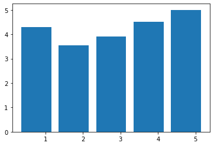

```python
import matplotlib.pyplot as plt
from numpy import arange

fig, ax = plt.subplots() #We can use pyplot.subplots() to first generate a single subplot and return both the Figure and Axes object. This is a shortcut from the technique we used in the previous mission:
num_cols = ['RT_user_norm', 'Metacritic_user_nom', 'IMDB_norm', 'Fandango_Ratingvalue', 'Fandango_Stars']

bar_heights = norm_reviews[num_cols].iloc[0].values # Heights of the bars.  In our case, the average rating for the first movie in the dataset.
bar_positions = arange(5) + 0.75 # Positions of the left sides of the 5 bars. [0.75, 1.75, 2.75, 3.75, 4.75]

ax.bar(bar_positions, bar_heights)
```

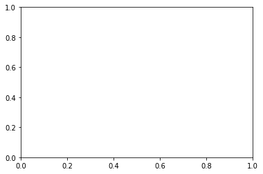

```python
fig, ax = plt.subplots()
```

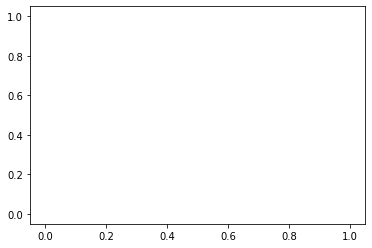

```python
plt.plot()
plt.show()
```

Create a single subplot and assign the returned Figure object to fig and the returned Axes object to ax. Generate a bar plot with: left set to bar_positions height set to bar_heights width set to 0.5 Use plt.show() to display the bar plot.

```
<BarContainer object of 5 artists>
```

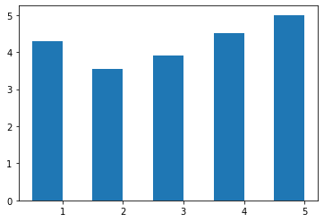

```python
fig, ax = plt.subplots()
ax.bar(bar_positions, bar_heights, 0.5)
```

```
[Text(0, 0, 'RT_user_norm'),
```

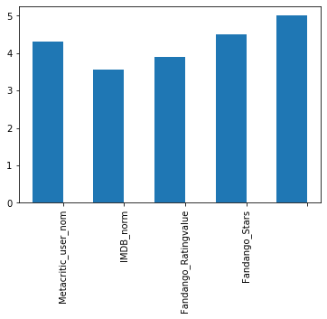

```python
## EFFECT WITHOUT

#tick_positions = range(1,6)
#ax.set_xticks(tick_positions)

fig, ax = plt.subplots()
ax.bar(bar_positions, bar_heights, 0.5)

num_cols = ['RT_user_norm', 'Metacritic_user_nom', 'IMDB_norm', 'Fandango_Ratingvalue', 'Fandango_Stars']
ax.set_xticklabels(num_cols, rotation = 90)
```

```
[Text(0, 0, 'RT_user_norm'),
```

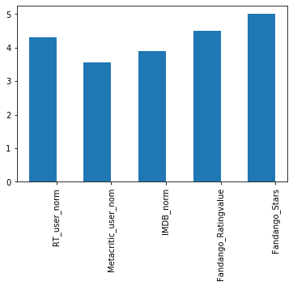

```python
fig, ax = plt.subplots()

ax.bar(bar_positions, bar_heights, 0.5)

tick_positions = range(1,6) #setting of positions of ticks
ax.set_xticks(tick_positions)

num_cols = ['RT_user_norm', 'Metacritic_user_nom', 'IMDB_norm', 'Fandango_Ratingvalue', 'Fandango_Stars']
ax.set_xticklabels(num_cols, rotation = 90) #Then, we can use Axes.set_xticklabels() to specify the tick labels:
```

Create a single subplot and assign the returned Figure object to fig and the returned Axes object to ax. Generate a bar plot with: left set to bar_positions height set to bar_heights width set to 0.5 Set the x-axis tick positions to tick_positions. Set the x-axis tick labels to num_cols and rotate by 90 degrees. Set the x-axis label to "Rating Source". Set the y-axis label to "Average Rating". Set the plot title to "Average User Rating For Avengers: Age of Ultron (2015)". Use plt.show() to display the bar plot.

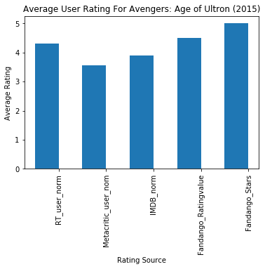

```python
fig, ax = plt.subplots()

num_cols = ['RT_user_norm', 'Metacritic_user_nom', 'IMDB_norm', 'Fandango_Ratingvalue', 'Fandango_Stars']
bar_heights = norm_reviews[num_cols].iloc[0].values
bar_positions = arange(5) + 0.75
tick_positions = range(1,6)

ax.bar(bar_positions, bar_heights, 0.5)
ax.set_xticks(tick_positions) #ax.set_xticks for position
ax.set_xticklabels(num_cols, rotation = 90) #ax.set_xticklabels for renaming and rotating of x axis labels
ax.set_xlabel('Rating Source') # vs plt.xlabel()
ax.set_ylabel('Average Rating') # vs plt.ylabel()
ax.set_title('Average User Rating For Avengers: Age of Ultron (2015)') # vs plt.title()

#begin all adjustments with set
#difference between set_xticklabels[Label for each bar] AND set_xlabels[Rating Source]

plt.show()
```

We can create a horizontal bar plot in matplotlib in a similar fashion. Instead of using Axes.bar(), we use **Axes.barh(). This method has 2 required parameters, bottom and width**. **We use the bottom parameter to specify the y coordinate for the bottom sides for the bars and the width parameter to specify the lengths of the bars:**

```python
bar_widths = norm_reviews[num_cols].iloc[0].values
bar_positions = arange(5) + 0.75
ax.barh(bar_positions, bar_widths, 0.5)
```

```
<BarContainer object of 5 artists>
```

To recreate the bar plot from the last step as horizontal bar plot, we essentially need to map the properties we set for the y-axis instead of the x-axis. We use Axes.set_yticks() to set the y-axis tick positions to [1, 2, 3, 4, 5] and Axes.set_yticklabels() to set the tick labels to the column names:

```python
tick_positions = range(1,6)
num_cols = ['RT_user_norm', 'Metacritic_user_nom', 'IMDB_norm', 'Fandango_Ratingvalue', 'Fandango_Stars']
ax.set_yticks(tick_positions)
ax.set_yticklabels(num_cols)
```

```
[Text(0, 0.0, 'RT_user_norm'),
```

Create a single subplot and assign the returned Figure object to fig and the returned Axes object to ax. Generate a bar plot with: bottom set to bar_positions width set to bar_widths height set to 0.5 Set the y-axis tick positions to tick_positions. Set the y-axis tick labels to num_cols. Set the y-axis label to "Rating Source". Set the x-axis label to "Average Rating". Set the plot title to "Average User Rating For Avengers: Age of Ultron (2015)". Use plt.show() to display the bar plot.

[figure not shown]

```python
import matplotlib.pyplot as plt
from numpy import arange
num_cols = ['RT_user_norm', 'Metacritic_user_nom', 'IMDB_norm', 'Fandango_Ratingvalue', 'Fandango_Stars']

bar_widths = norm_reviews[num_cols].iloc[0].values
bar_positions = arange(5) + 0.75
tick_positions = range(1,6)

fig, ax = plt.subplots()

ax.barh(bar_positions, bar_widths, 0.5)
ax.set_yticks(tick_positions) #ticks have PLURAL labels
ax.set_yticklabels(num_cols) #ticks have PLURAL labels #barh, no need to rotate
ax.set_ylabel('Rating Source') #SINGULAR label
ax.set_xlabel('Average Rating') #SINGULAR label
ax.set_title("Average User Rating For Avengers: Age of Ultron (2015)")

plt.show()
```

To generate a scatter plot, we use **Axes.scatter(). The scatter() method has 2 required parameters, x and y, which matches the parameters of the plot() method.** The values for these parameters need to be iterable objects of matching lengths (lists, NumPy arrays, or pandas series).

Create a single subplot and assign the returned Figure object to fig and the returned Axes object to ax. Generate a scatter plot with the Fandango_Ratingvalue column on the x-axis and the RT_user_norm column on the y-axis. Set the x-axis label to "Fandango" and the y-axis label to "Rotten Tomatoes". Use plt.show() to display the resulting plot.

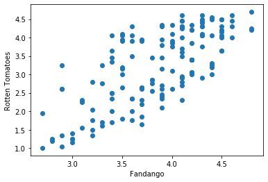

```python
fig, ax = plt.subplots()

ax.scatter(norm_reviews['Fandango_Ratingvalue'], norm_reviews['RT_user_norm'])
ax.set_xlabel('Fandango')
ax.set_ylabel('Rotten Tomatoes')

plt.show()
```

We have provided starter code as comments in the code editor. Select all of these lines and press ctrl + / (PC) or ⌘ + / (Mac) to uncomment these lines so you can use it. For a demo of how this keyboard shortcut works, see this help article.

For the subplot associated with ax1: Generate a scatter plot with the Fandango_Ratingvalue column on the x-axis and the RT_user_norm column on the y-axis. Set the x-axis label to "Fandango" and the y-axis label to "Rotten Tomatoes". For the subplot associated with ax2:

Generate a scatter plot with the RT_user_norm column on the x-axis and the Fandango_Ratingvalue column on the y-axis. Set the x-axis label to "Rotten Tomatoes" and the y-axis label to "Fandango". Use plt.show() to display the resulting plot.

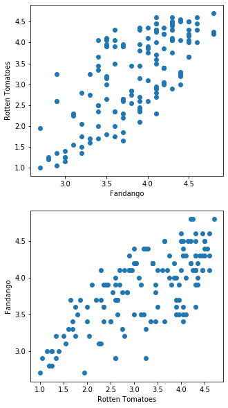

```python
fig = plt.figure(figsize=(5,10))
ax1 = fig.add_subplot(2,1,1)
ax2 = fig.add_subplot(2,1,2)
reviews = pd.read_csv('fandango_scores.csv')
cols = ['FILM', 'RT_user_norm', 'Metacritic_user_nom', 'IMDB_norm', 'Fandango_Ratingvalue', 'Fandango_Stars']
norm_reviews = reviews[cols]

ax1.scatter(norm_reviews['Fandango_Ratingvalue'],norm_reviews['RT_user_norm'])
ax1.set_xlabel('Fandango')
ax1.set_ylabel('Rotten Tomatoes')

ax2.scatter(norm_reviews['RT_user_norm'],norm_reviews['Fandango_Ratingvalue'])
ax2.set_xlabel('Rotten Tomatoes')
ax2.set_ylabel('Fandango')
```

For example, the following code will limit the axes to the 4 to 5 range:

ax.set_xlim(4, 5) ax.set_ylim(4, 5)

We have provided starter code as comments in the code editor. Select all of these lines and press ctrl + / (PC) or ⌘ + / (Mac) to uncomment these lines so you can use it. For a demo of how this keyboard shortcut works, see this help article.

For the Subplot associated with ax1: Generate a scatter plot with the Fandango_Ratingvalue column on the x-axis and the RT_user_norm column on the y-axis. Set the x-axis label to "Fandango" and the y-axis label to "Rotten Tomatoes". Set the x-axis and y-axis data limits to range from 0 and 5. For the Subplot associated with ax2: Generate a scatter plot with the Fandango_Ratingvalue column on the x-axis and the Metacritic_user_nom column on the y-axis. Set the x-axis label to "Fandango" and the y-axis label to "Metacritic". Set the x-axis and y-axis data mlimits to range from 0 and 5. For the Subplot associated with ax3: Generate a scatter plot with the Fandango_Ratingvalue column on the x-axis and the IMDB_norm column on the y-axis. Set the x-axis label to "Fandango" and the y-axis label to "IMDB". Set the x-axis and y-axis data limits to range from 0 and 5. Use plt.show() to display the plots.

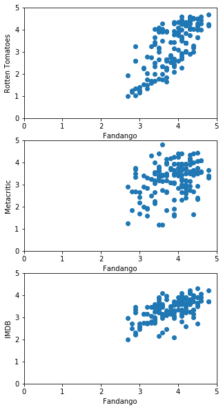

```python
fig = plt.figure(figsize=(5,10))
ax1 = fig.add_subplot(3,1,1)
ax2 = fig.add_subplot(3,1,2)
ax3 = fig.add_subplot(3,1,3)

ax1.scatter(norm_reviews['Fandango_Ratingvalue'],norm_reviews['RT_user_norm'])
ax1.set_xlabel('Fandango')
ax1.set_ylabel('Rotten Tomatoes')
ax1.set_xlim(0,5)
ax1.set_ylim(0,5)

ax2.scatter(norm_reviews['Fandango_Ratingvalue'],norm_reviews['Metacritic_user_nom'])
ax2.set_xlabel('Fandango')
ax2.set_ylabel('Metacritic')
ax2.set_xlim(0,5)
ax2.set_ylim(0,5)

ax3.scatter(norm_reviews['Fandango_Ratingvalue'],norm_reviews['IMDB_norm'])
ax3.set_xlabel('Fandango')
ax3.set_ylabel('IMDB')
ax3.set_xlim(0,5)
ax3.set_ylim(0,5)

plt.show()
```